# CIFAR-10 - ConvNet w/ Image Augmentation

- Name: Tan Yu Hoe
- Admin No: P2026309
- Class: DAAA/FT/2B/04

## Motivation

This notebook is purposed to train and evaluate a Convolution Neural Network on CIFAR-10 dataset, implementing Image Augmentation. Experimentation results are run and stored in **Weights and Biases**

## Personal Objectives

These are objectives / goals for myself to accomplish while attempting to perform image classification for the CIFAR-10 dataset.

1. Obtain a high test accuracy compared to public benchmark (The average benchmark for CIFAR-10 is about 85% Test Accuracy)
2. Experiment with multiple training strategies and CNN architectures

## !! Important Note !!

As this is an experimentation run, I would not go so in depth into Exploratory Data Analysis, Image Processing, and the Neural Network Archtecture ( Using a Baseline ConvNet ) itself. The markdown headers are used as checkpoints for me to better navigate around the notebook using Google Colaboratory.

```python
# import relevant libraries/classes/dependencies
import os
import random

import matplotlib.pyplot as plt
import seaborn as sns
import numpy as np
import pandas as pd
import tensorflow as tf
from tensorflow import keras
from tensorflow.keras.datasets import cifar10
import datetime
!pip install -q pytz
import pytz
sg = pytz.timezone("Singapore")

# Set the random seeds - to ensure reproducibility
os.environ['TF_CUDNN_DETERMINISTIC'] = "1"
random.seed(1)
np.random.seed(1)
tf.random.set_seed(1)
```

```python
# Matplotlib Stylings
plt.rcParams['figure.figsize'] = (12, 6)
plt.rcParams['figure.autolayout'] = True
plt.style.use('fivethirtyeight')
```

## Setting up **Weights and Biases**

```python
# install and configure weights and biases
!pip install -q wandb
import wandb
from wandb.keras import WandbCallback
wandb.login()
```

```
     |████████████████████████████████| 1.7 MB 5.2 MB/s
     |████████████████████████████████| 140 kB 50.0 MB/s
     |████████████████████████████████| 180 kB 51.4 MB/s
     |████████████████████████████████| 97 kB 6.6 MB/s
     |████████████████████████████████| 63 kB 1.8 MB/s
```

```
wandb: Appending key for api.wandb.ai to your netrc file: /root/.netrc
```

```
True
```

## Training on a Tesla P100-PCIE-16GB

```python
# Checking if GPU is available
from tensorflow.python.client import device_lib
print(device_lib.list_local_devices())
```

```
[name: "/device:CPU:0"
device_type: "CPU"
memory_limit: 268435456
locality {
}
incarnation: 17914657422470772119
xla_global_id: -1
, name: "/device:GPU:0"
device_type: "GPU"
memory_limit: 16154099712
locality {
  bus_id: 1
  links {
  }
}
incarnation: 11515273590723629080
physical_device_desc: "device: 0, name: Tesla P100-PCIE-16GB, pci bus id: 0000:00:04.0, compute capability: 6.0"
xla_global_id: 416903419
]
```

## Data Injestion

```python
# Import numpy
(x_train, y_train), (x_test, y_test) = cifar10.load_data()
y_train = y_train.reshape(-1)
y_test  = y_test.reshape(-1)

# Lookup Table for Class Names
classes = ['airplane', 'automobile', 'bird', 'cat', 'deer',
               'dog', 'frog', 'horse', 'ship', 'truck']
print('Dataset Loaded')
```

```
Downloading data from https://www.cs.toronto.edu/~kriz/cifar-10-python.tar.gz
Dataset Loaded
```

```python
# Shape of Training and Testing Sets
print("X_train:", x_train.shape, "y_train:", y_train.shape)
print("X_test:", x_test.shape, "y_test:", y_test.shape)
```

```
X_train: (50000, 32, 32, 3) y_train: (50000,)
X_test: (10000, 32, 32, 3) y_test: (10000,)
```

```python
# Import Keras Functions
from tensorflow.keras import Input
from tensorflow.keras.models import Sequential, Model
from tensorflow.keras.layers import *
from tensorflow.keras.optimizers import *
from tensorflow.keras.callbacks import *
from tensorflow.keras.utils import plot_model
from tensorflow.nn import local_response_normalization
from tensorflow.keras.preprocessing.image import ImageDataGenerator
from tensorflow.keras.utils import to_categorical
```

## Feature Engineering

```python
def preprocessing_func(x, y):
    # process X
    x = tf.cast(x, tf.float32) # convert to float32 first
    x = Rescaling(1./127.5, offset=-1)(x)

    return x, y

# transform
x_train, y_train = preprocessing_func(x_train, y_train)
x_test, y_test = preprocessing_func(x_test, y_test)

print("Training Shape:", x_train.shape, y_train.shape)
print("Testing Shape:", x_train.shape, y_test.shape)
```

```
Training Shape: (50000, 32, 32, 3) (50000,)
Testing Shape: (50000, 32, 32, 3) (10000,)
```

## Image Augmentation

Let's do a quick google search and look for the definition of image augmentation.

> Image data augmentation is a technique that can be used to artificially expand the size of a training dataset by creating modified versions of images in the dataset. ... Image data augmentation is used to expand the training dataset in order to improve the performance and ability of the model to generalise. [[Source](https://machinelearningmastery.com/how-to-configure-image-data-augmentation-when-training-deep-learning-neural-networks/)]

Convolution Neural Networks has an ability to greatly generalise/capture the underlying structure of the training images provided. This creates a tendency of overfitting in the model, having a large variance between the training and validation data provided.

By using Image Augmentation, we create more variations of the training images provided, improving the performance of the model of better generalisation. The Keras API provides us a class `ImageDataGenerator` to easily perform image augmentation by generating batches of augmented image tensors.

[output not shown]

### Cutout / Random Erasing

Cutout or Random Erasing is a kind of image augmentation methods for ConvNet. It tries to regularize models using training images that are randomly masked with random values. [1][2]

By generating images with random masks, it better prepares the models by learning to take more features of the images into consideration before making an prediction/ouptut.

The Keras/Tensorflow does not provide any classes/function (or not that I know of) to do random Cutout in images. Thus, I sourced for the function in a GitHub repository to do this for me. Then, I integrate this function within the `ImageDataGenerator` class along with other types of augmentation.

[output not shown]

[output not shown]

- [1] T. DeVries and G. W. Taylor, "Improved Regularization of Convolutional Neural Networks with Cutout," in arXiv:1708.04552, 2017.
- [2] Z. Zhong, L. Zheng, G. Kang, S. Li, and Y. Yang, "Random Erasing Data Augmentation," in arXiv:1708.04896, 2017.

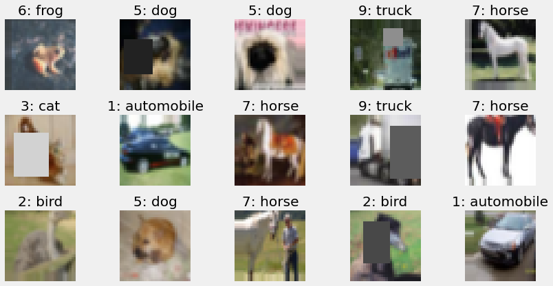

```python
## source code: https://github.com/yu4u/mixup-generator/blob/master/random_eraser.py
def get_random_eraser(p=0.5, s_l=0.02, s_h=0.4, r_1=0.3, r_2=1/0.3, v_l=0, v_h=255):
    def eraser(input_img):
        img_h, img_w, _ = input_img.shape
        p_1 = np.random.rand()

        if p_1 > p:
            return input_img

        while True:
            s = np.random.uniform(s_l, s_h) * img_h * img_w
            r = np.random.uniform(r_1, r_2)
            w = int(np.sqrt(s / r))
            h = int(np.sqrt(s * r))
            left = np.random.randint(0, img_w)
            top = np.random.randint(0, img_h)

            if left + w <= img_w and top + h <= img_h:
                break

        c = np.random.uniform(v_l, v_h)
        input_img[top:top + h, left:left + w, :] = c

        return input_img

    return eraser

# prepare image data generator for augmentation
train_datagen = ImageDataGenerator(
    width_shift_range=0.1,
    height_shift_range=0.1,
    horizontal_flip=True,
    preprocessing_function=get_random_eraser(v_l=-1, v_h=1),
    validation_split=0.1,
)

# display images from
example_ds = train_datagen.flow(x=x_train, y=y_train)
fig = plt.figure()
for i in range(15):
    img, label = example_ds.next()
    ax = fig.add_subplot(3, 5, i+1)
    ax.imshow((img[0] + 1) / 2)
    ax.set_title(f"{label[0]}: {classes[label[0]]}")
    ax.axis('off')
plt.show()
```

## Baseline Model w/ Image Augmentation

For the model, I did not make any change to the baseline ConvNet I've implemented earlier on. I intend to run experiementation tracking to do a comparison between the baseline architecture with/without Image Augmentation.

```python
def conv_block(neurons: int, num: int):
    '''
    Creates a generic Hidden Conv2D Layer with ReLU Activations
    Including Batch Normalization and Max Pooling Layers

    Args:
        - neurons: number of neurons in the dense layer
        - num    : block number
        - kernel size: height and width of Convolution 2D window (k, k)
          - default: 3
    '''
    block = Sequential(name=f'Covolution_Block_{num}')
    block.add(Conv2D(neurons, kernel_size=(3, 3),
                     activation='relu', strides=1, padding='same', kernel_initializer='he_normal'))
    block.add(BatchNormalization())
    block.add(MaxPooling2D(pool_size=(2, 2), strides=2, padding='same'))

    return block
```

```python
# Densely Connected Blocks
def dense_block(neurons: int, num: int, dropout:float):
    '''
    Creates a generic Hidden Dense Layer with ReLU Activations
    Including Dropout and Batch Normalization layers

    Args:
        - neurons: number of neurons in the dense layer
        - num    : block number
        - dropout: proportion of weights to apply dropout
    '''
    block = Sequential(name=f'Dense_Block_{num}')
    block.add(Dense(neurons, activation='relu', kernel_initializer='he_normal'))
    block.add(BatchNormalization())
    block.add(Dropout(dropout))

    return block
```

```python
def baseline_builder(input_shape=(32, 32, 3)):
    model = Sequential(name='Baseline')

    # Input and Feature Engineering
    model.add(Input(input_shape, name='Input_Layer'))

    # Convolutional Block - Feature Extraction
    for layer_num in range(1):
        model.add(conv_block(64, layer_num))

    # Flatten Layer - the middle layer between convolutional and densely connected layers
    model.add(Flatten(name='Flatten'))

    # Densely Connected Nodes - Classification Block
    for layer_num in range(1):
        model.add(dense_block(64, layer_num, 0.5))

    # Output Layer - Softmax Activation
    model.add(Dense(10, activation='softmax', name='Softmax_Output_Layer'))

    return model
```

## Model Configuration and Building

Most of the model's hyperparameters (eg. batch size, learning rate) are stored within a configuration class within **Weights and Biases**.

```python
# Initialise Weights and Biases run
current_time = datetime.datetime.now(sg).strftime("%d:%m:%Y_%H:%M")
run = wandb.init(
    project="CIFAR-10 ConvNet",
    name=f"Baseline_ConvNet w/ Image Augmentation {[current_time]}",
    config={
        "learning_rate": 0.001,
        "epochs": 50,
        "batch_size": 512,
        "loss_function": "sparse_categorical_crossentropy",
        "architecture": "Baseline ConvNet w/ Image Augmentation",
        "dataset": "CIFAR-10"
    },
    group="Baseline ConvNet w/ Image Augmentation"
)

# Prepare Configurations
config = wandb.config

# Build the Network
tf.keras.backend.clear_session() # Resets all state generated by Keras
baseline = baseline_builder()
baseline.summary()

# Preparing Optimizer
optimizer = Adam(learning_rate=config.learning_rate)

# Compiling - Adam Optimizer Categorical Cross Entropy Loss Function
baseline.compile(
    optimizer=optimizer,
    loss=config.loss_function,
    metrics=['accuracy']
)
```

```
wandb: Currently logged in as: tyh71 (use `wandb login --relogin` to force relogin)
```

Syncing run **[Baseline_ConvNet w/ Image Augmentation ['23:11:2021_20:17']](https://wandb.ai/tyh71/CIFAR-10%20ConvNet/runs/1lnl5x61)** to [Weights & Biases](https://wandb.ai/tyh71/CIFAR-10%20ConvNet) ([docs](https://docs.wandb.com/integrations/jupyter.html)).

```
Model: "Baseline"
_________________________________________________________________
 Layer (type)                Output Shape              Param #
=================================================================
 Covolution_Block_0 (Sequent  (None, 16, 16, 64)       2048
 ial)

 Flatten (Flatten)           (None, 16384)             0

 Dense_Block_0 (Sequential)  (None, 64)                1048896

 Softmax_Output_Layer (Dense  (None, 10)               650
 )

=================================================================
Total params: 1,051,594
Trainable params: 1,051,338
Non-trainable params: 256
_________________________________________________________________
```

```python
# Final Set of Callbacks
callbacks = [
    WandbCallback(save_model=True),
]
```

```python
%%time
# Train Model
baseline_hist = baseline.fit(
    x=train_datagen.flow(x_train, y_train, subset='training', batch_size=config.batch_size),
    validation_data=train_datagen.flow(x_train, y_train, subset='validation', batch_size=config.batch_size),
    epochs=config.epochs,
    verbose=1,
    use_multiprocessing=True,
    workers=32,
    callbacks=callbacks
)
run.finish()
```

Waiting for W&B process to finish, PID 207... **(success).**

Run history:

| accuracy | ▁▃▄▅▅▆▆▆▇▇▇▇▇▇▇▇▇▇▇▇▇▇▇█▇███████████████ |
| --- | --- |
| epoch | ▁▁▁▁▂▂▂▂▂▃▃▃▃▃▃▄▄▄▄▄▅▅▅▅▅▅▆▆▆▆▆▆▇▇▇▇▇███ |
| loss | █▅▄▄▃▃▃▂▂▂▂▂▂▂▂▂▂▂▂▂▁▁▁▁▁▁▁▁▁▁▁▁▁▁▁▁▁▁▁▁ |
| val_accuracy | ▁▂▄▄▅▆▆▆▆▇▇▇▇▇▇▇▇▇▇▇▇▇▇▇▇▇▇▇████████████ |
| val_loss | █▇▆▅▃▃▃▃▂▂▂▂▂▂▂▂▂▂▂▂▂▁▁▂▂▁▁▁▁▁▁▁▁▁▁▁▁▁▁▁ |

Run summary:

| accuracy | 0.61338 |
| --- | --- |
| best_epoch | 48 |
| best_val_loss | 0.99002 |
| epoch | 49 |
| loss | 1.09202 |
| val_accuracy | 0.6444 |
| val_loss | 1.00839 |

Synced 5 W&B file(s), 1 media file(s), 0 artifact file(s) and 1 other file(s)  
Synced **Baseline_ConvNet w/ Image Augmentation ['23:11:2021_20:17']**: https://wandb.ai/tyh71/CIFAR-10%20ConvNet/runs/1lnl5x61  
Find logs at: `./wandb/run-20211123_121751-1lnl5x61/logs`

```
CPU times: user 2min 16s, sys: 5min 28s, total: 7min 45s
Wall time: 16min 25s
```

```python
# in case of model training being interrupted
run.finish()
```

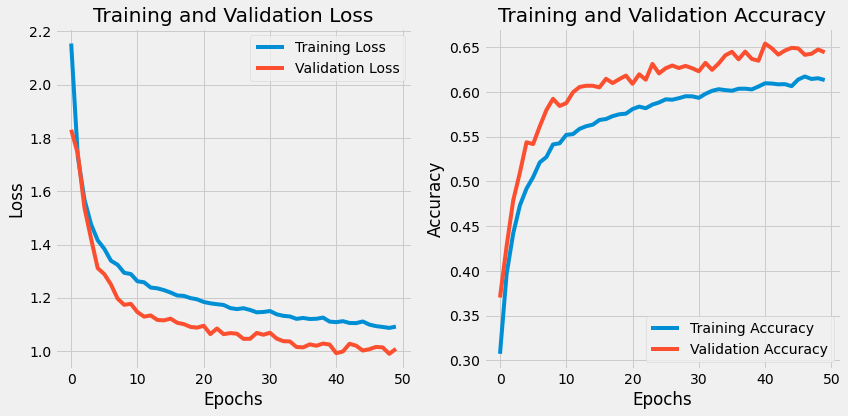

```python
# Plot Learning Curves
fig, (ax1, ax2) = plt.subplots(1, 2, figsize=(12, 6), tight_layout=True)

ax1.plot(baseline_hist.history['loss'], label='Training Loss')
ax1.plot(baseline_hist.history['val_loss'], label='Validation Loss')
ax1.set_title('Training and Validation Loss')
ax1.set_xlabel('Epochs')
ax1.set_ylabel('Loss')
ax1.legend()

ax2.plot(baseline_hist.history['accuracy'], label='Training Accuracy')
ax2.plot(baseline_hist.history['val_accuracy'], label='Validation Accuracy')
ax2.set_title('Training and Validation Accuracy')
ax2.set_xlabel('Epochs')
ax2.set_ylabel('Accuracy')
ax2.legend()

plt.show()
```

```python
# Evaluating Training and Testing Set
train = baseline.evaluate(x_train, y_train)
test  = baseline.evaluate(x_test, y_test)

# Creating a Logger to store all Evaluation Results
logger = pd.DataFrame(columns=['Train Loss', 'Train Acc', 'Test Loss', 'Test Acc'])
logger = logger.append(
    pd.Series(
        {
            'Train Loss': train[0],
            'Train Acc' : train[1],
            'Test Loss' : test[0],
            'Test Acc'  : test[1],
            'Test Percentage Error': "{:.2%}".format(1.0 - test[1])
        },
        name='Baseline ConvNet',))
logger
```

|  | Train Loss | Train Acc | Test Loss | Test Acc | Test Percentage Error |
| --- | --- | --- | --- | --- | --- |
| Baseline ConvNet | 0.853648 | 0.69718 | 0.916447 | 0.6761 | 32.39% |

## Model Evaluation

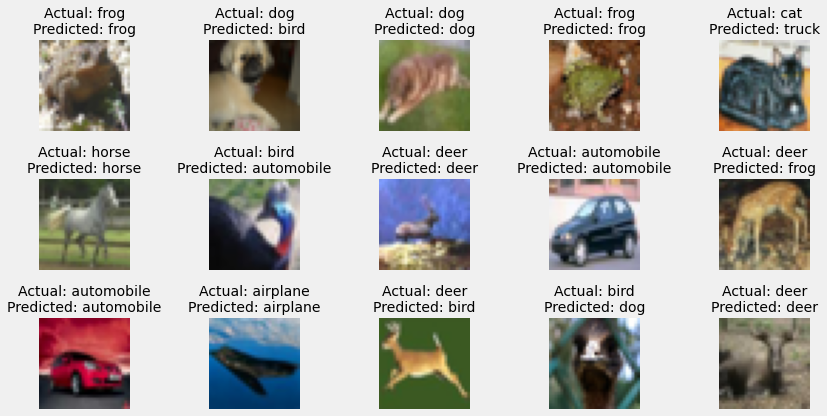

```python
# Predict the values from the test dataset
y_pred = baseline.predict(x_test)
# Convert predictions classes to one hot encoded vectors
y_pred_class = np.argmax(y_pred, axis = 1)

w = 5
h = 3
fig = plt.figure(figsize=(12, 6), tight_layout=True)
for i in range(w*h):
  rand_idx = np.random.randint(0, len(x_test))
  ax = fig.add_subplot(h, w, i+1)
  ax.imshow((tf.reshape(x_test[rand_idx], (32, 32, 3))+1)/2)
  ax.axis('off')
  ax.set_title(f'Actual: {classes[y_test[rand_idx]]}\nPredicted: {classes[y_pred_class[rand_idx]]}', fontsize=14)
plt.show()
```

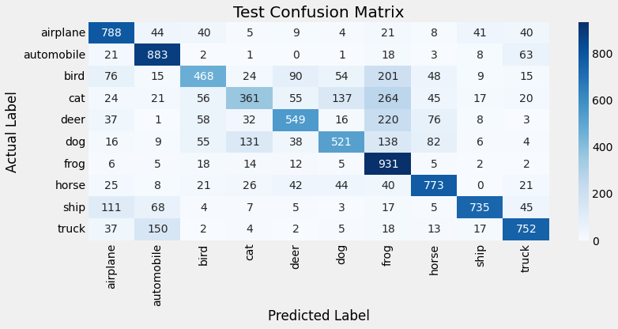

```python
from sklearn.metrics import confusion_matrix
# compute the confusion matrix
confusion_mtx = confusion_matrix(y_test, y_pred_class)

sns.heatmap(confusion_mtx, cmap='Blues', annot=True, xticklabels=classes, yticklabels=classes, fmt='.3g')
plt.title('Test Confusion Matrix')
plt.xticks(rotation=90)
plt.xlabel('Predicted Label')
plt.ylabel('Actual Label')
plt.show()
```

```python
from sklearn.metrics import classification_report
# print out classification report
print(classification_report(y_test, y_pred_class, target_names=classes))
```

```
              precision    recall  f1-score   support

    airplane       0.69      0.79      0.74      1000
  automobile       0.73      0.88      0.80      1000
        bird       0.65      0.47      0.54      1000
         cat       0.60      0.36      0.45      1000
        deer       0.68      0.55      0.61      1000
         dog       0.66      0.52      0.58      1000
        frog       0.50      0.93      0.65      1000
       horse       0.73      0.77      0.75      1000
        ship       0.87      0.73      0.80      1000
       truck       0.78      0.75      0.77      1000

    accuracy                           0.68     10000
   macro avg       0.69      0.68      0.67     10000
weighted avg       0.69      0.68      0.67     10000
```

## Observations and Further Improvements

- The model has better generalisation of the training data with augmentation, with the validation loss continue to decrease for a longer number of epochs
- There is a decrease in both Training and Validation accuracy, which is likely due to the regularization effect from Image Augmentation.
- In conclusion, we have somewhat found the solution to the model overfitting issue - to use Image Augmentation.
- For the next step, I want to edit and change the model architecture by making it deeper, in order to obtain better performance in test accuracy.

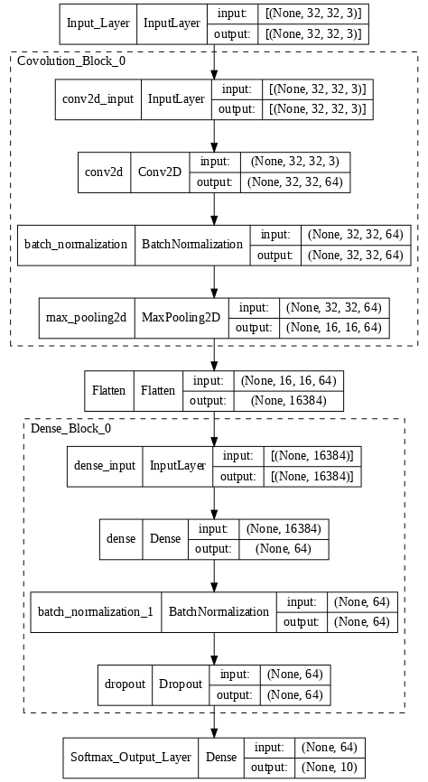

```python
# Display Model Architecture in Notebook Output
from tensorflow.keras.utils import plot_model
plot_model(baseline, show_shapes=True, show_dtype=False,
    show_layer_names=True, expand_nested=True, dpi=70)
```